# Proyecto asignatura Estadística (MAT3) GIN2 Grupos 1 y 3: PARTE 1 Curso 2020-2021

Marc Cañellas, Eduardo Bonnin, Jaume Adrover, Joan Balaguer

23/4/2021

1. Cargad en un `dataframe` los datos del fichero `listings.csv` (descomprimido a partir de `listings.csv.gz`). Esta tabla de datos contiene datos sobre muchas variables:
   - `neighbourhood property_type`
   - `accommodates`
   - `beds`
   - `bedrooms`
   - `bathrooms`
   - `price`
   - `security_deposit`
   - `minimum_nights`
   - `review_scores_rating`
   - `number_of_reviews`
   - `host_response_time`
   - `requires_license`
   - `review_scores_cleanliness`
   - `cleaning_fee`
   - `etc.`  
     Construid un nuevo `data frame` que contenga solo la información relativa a como mínimo 3 variables no numéricas y 7 variables numéricas. Hay que **escoger forma obligatoria las variables** `neighbourhood` y `price`. Las variables relativas a precioso (por ejemplo, `price` y `security_deposit`) se consideran numéricas, pero primero deben convertirse a valores numéricos eliminando los símbolos `$` o `€`; por ejemplo utilizando la función `gsub(pattern="[\\$]",replacement="",x="$10,000")`; haced (`help(gsub)`)
2. Renombrar las columnas del `dataframe` con nombres en castellano o catalán.

## Solución apartados 1 y 2

A nuestro grupo (`Los Discretos`), le ha tocado la ciudad de Western Australia. Vamos a cargar los datos del documento de datos listing.csv en un data frame que llamaremos `AUS`. En nuestro caso, este data frame estará conformado por las variables cuantitativas `price`,`latitude`,`longitude`,`bedrooms`,`beds`,`acomodates` y `minimum_nights`, y las variables cualitativas `host_id`,`host_name`,`neighbourhood` y `host_location` del archivo de donde hemos leido los datos. En el aprtado 2, hemos modificado estos nombres y los hemos sustituido por sus respectivos nombres en español.

```r
#Cargamos los Datos
df=read.csv("listings.csv", header=TRUE)
#Cuantitativas
precio=as.numeric(gsub(pattern = "[\\$]|[,]",replacement = "", df$price))
latitud=df$latitude
longitud=df$longitude
dormitorios=df$bedrooms
camas=df$beds
acomodaciones=df$accommodates
noches_minimas=df$minimum_nights

#Cualitativas
id_anfitrion=df$host_id
nombre_anfitrión=df$host_name
vecindario=df$neighbourhood
localización=df$host_location

#Creamos nuestro Data Frame llamado AUS
AUS = data.frame(precio,
                 latitud,
                 longitud,
                 dormitorios,
                 camas,
                 acomodaciones,
                 noches_minimas,
                 id_anfitrion,
                 nombre_anfitrión,
                 vecindario,
                 localización
                 )

#Vemos la estructura general de nustro data frame
str(AUS)
```

```
## 'data.frame':    7069 obs. of  11 variables:
##  $ precio          : num  95 64 94 220 65 70 74 156 100 70 ...
##  $ latitud         : num  -32 -32.1 -29.3 -34.4 -32.1 ...
##  $ longitud        : num  116 116 115 116 116 ...
##  $ dormitorios     : int  2 1 1 5 1 1 1 2 1 1 ...
##  $ camas           : int  3 1 1 6 1 1 1 2 1 1 ...
##  $ acomodaciones   : int  5 1 2 8 1 2 2 4 2 2 ...
##  $ noches_minimas  : int  2 1 1 2 1 2 2 5 1 2 ...
##  $ id_anfitrion    : int  2313 162227 186576 277321 284743 319052 348191 431695 275749 474393 ...
##  $ nombre_anfitrión: chr  "Helen" "Theja" "Denise" "Karen" ...
##  $ vecindario      : chr  "Como, Western Australia, Australia" "" "Dongara, Western Australia, Australia" "Smith Brook, Western Australia, Australia" ...
##  $ localización    : chr  "Perth, Western Australia, Australia" "Perth, Western Australia, Australia" "AU" "Southwest West Australia" ...
```

3. Para las variables numéricas, calcular los siguientes estadísticos y mostrar en una tabla los siguiente valores: cantidad de valores no válidos, mínimo, máximo, media, varianza, cuartiles y mediana.

## Solución apartado 3

```r
#Hemos creado una funcion que implementa todos los calculos del apartado 3
apartado3=function(x){
    c(
    #Media
    media=mean(x,na.rm = TRUE),
    #Mediana
    mediana=median(x,na.rm = TRUE),
    #Maximo
    max=max(x,na.rm = TRUE),
    #Mínimo
    min=min(x,na.rm = TRUE),
    #Cuartil0.25
    cuantil1=quantile(x,0.25,na.rm = TRUE),
    #Cuartil0.5
    cuantil2=quantile(x,0.5,na.rm = TRUE),
    #Cuartil0.75
    cuantil3=quantile(x,0.75,na.rm = TRUE),
    #Varianza
    varianza=var(x,na.rm = TRUE)*(length(x)-1)/length(x),
    #El numero de NA's
    mumeroNA=ifelse(is.na(table(is.na(x))[2]),0,table(is.na(x))[2]))
}

#Aplicamos la función apartado3 con cada una de las variables cuantitativas elegidas
salida= apply(AUS[,1:7], MARGIN = 2, FUN = apartado3)
rownames(salida)=c("Media","Mediana","Maximo","Mínimo","Cuartil0.25","Cuartil0.5","Cuartil0.75","Varianza","Numero de NA's")
knitr::kable(salida)
```

|  | precio | latitud | longitud | dormitorios | camas | acomodaciones | noches_minimas |
| --- | --- | --- | --- | --- | --- | --- | --- |
| Media | 206.9281 | -32.139216 | 115.983934 | 2.210996 | 3.013318 | 4.698783 | 3.394878 |
| Mediana | 150.0000 | -32.051105 | 115.767255 | 2.000000 | 2.000000 | 4.000000 | 2.000000 |
| Maximo | 14575.0000 | -15.719970 | 128.778580 | 50.000000 | 49.000000 | 16.000000 | 365.000000 |
| Mínimo | 15.0000 | -35.090420 | 113.528300 | 1.000000 | 0.000000 | 1.000000 | 1.000000 |
| Cuartil0.25 | 95.0000 | -33.638060 | 115.332077 | 1.000000 | 1.000000 | 2.000000 | 1.000000 |
| Cuartil0.5 | 150.0000 | -32.051105 | 115.767255 | 2.000000 | 2.000000 | 4.000000 | 2.000000 |
| Cuartil0.75 | 244.0000 | -31.924660 | 115.894752 | 3.000000 | 4.000000 | 6.000000 | 3.000000 |
| Varianza | 139933.1312 | 6.918094 | 2.089626 | 2.110338 | 5.106653 | 8.080887 | 159.042575 |
| Numero de NA’s | 1.0000 | 1.000000 | 1.000000 | 230.000000 | 11.000000 | 1.000000 | 1.000000 |

4. Para las variables no numéricas, generad las tablas de frecuencias absolutas de cada uno de sus valores.

## Solución apartado 4

```r
#Frecuencias absolutas
tabla1=sort(table(AUS$nombre_anfitrión, exclude = ""),decreasing = TRUE, na.rm=TRUE)[1:10]
knitr::kable(tabla1, col.names = c("Nombres","Freq"))
```

| Nombres | Freq |
| --- | --- |
| Exclusiveescapes | 72 |
| Peter | 65 |
| Davinia | 58 |
| Michael | 55 |
| Chris | 53 |
| Lisa | 52 |
| Paul | 49 |
| Phoebe | 49 |
| Helen | 46 |
| Mary | 46 |

```r
tabla2=sort(table(AUS$vecindario, exclude = ""),decreasing = TRUE,na.rm=TRUE)[1:10]
knitr::kable(tabla2, col.names = c("Vecindarios","Freq"))
```

| Vecindarios | Freq |
| --- | --- |
| Margaret River, Western Australia, Australia | 235 |
| Fremantle, Western Australia, Australia | 196 |
| Perth, Western Australia, Australia | 171 |
| Dunsborough, Western Australia, Australia | 164 |
| Scarborough, Western Australia, Australia | 113 |
| Yallingup, Western Australia, Australia | 92 |
| Cottesloe, Western Australia, Australia | 67 |
| Subiaco, Western Australia, Australia | 66 |
| Cable Beach, Western Australia, Australia | 61 |
| West Perth, Western Australia, Australia | 60 |

```r
tabla3=sort(table(AUS$localización, exclude = ""),decreasing = TRUE,na.rm=TRUE)[1:10]
knitr::kable(tabla3, col.names = c("Localizaciones","Freq"))
```

| Localizaciones | Freq |
| --- | --- |
| Perth, Western Australia, Australia | 1489 |
| AU | 675 |
| Western Australia, Australia | 594 |
| Margaret River, Western Australia, Australia | 340 |
| Fremantle, Western Australia, Australia | 240 |
| Dunsborough, Western Australia, Australia | 184 |
| Busselton, Western Australia, Australia | 154 |
| Yallingup, Western Australia, Australia | 139 |
| Australia | 133 |
| Albany, Western Australia, Australia | 97 |

```r
tabla4=sort(table(AUS$id_anfitrion, exclude = ""),decreasing = TRUE,na.rm=TRUE)[1:10]
knitr::kable(tabla4, col.names = c("Identificadores","Freq"))
```

| Identificadores | Freq |
| --- | --- |
| 511967 | 72 |
| 15360130 | 58 |
| 73686458 | 41 |
| 106486177 | 41 |
| 170107339 | 34 |
| 269664436 | 31 |
| 33703497 | 27 |
| 215985827 | 26 |
| 22742955 | 25 |
| 34477031 | 25 |

5. Dibujar diagramas de cajas(**boxplots** ) e histogramas de todas las variables numéricas, mostrando un mínimo de 2 **boxplot** por fila. Ajustad la altura de los gráficos para que no queden demasiado pequeños.

## Solución apartado 5

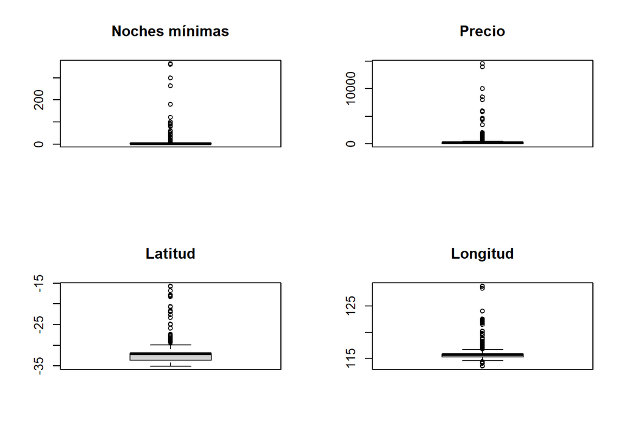

```r
#Boxplots de las variables cuantitativas
par(mfrow=c(2,2))

boxplot(AUS$noches_minimas,main="Noches mínimas")
boxplot(AUS$precio,main="Precio")
boxplot(AUS$latitud,main="Latitud")
boxplot(AUS$longitud,main="Longitud")
```

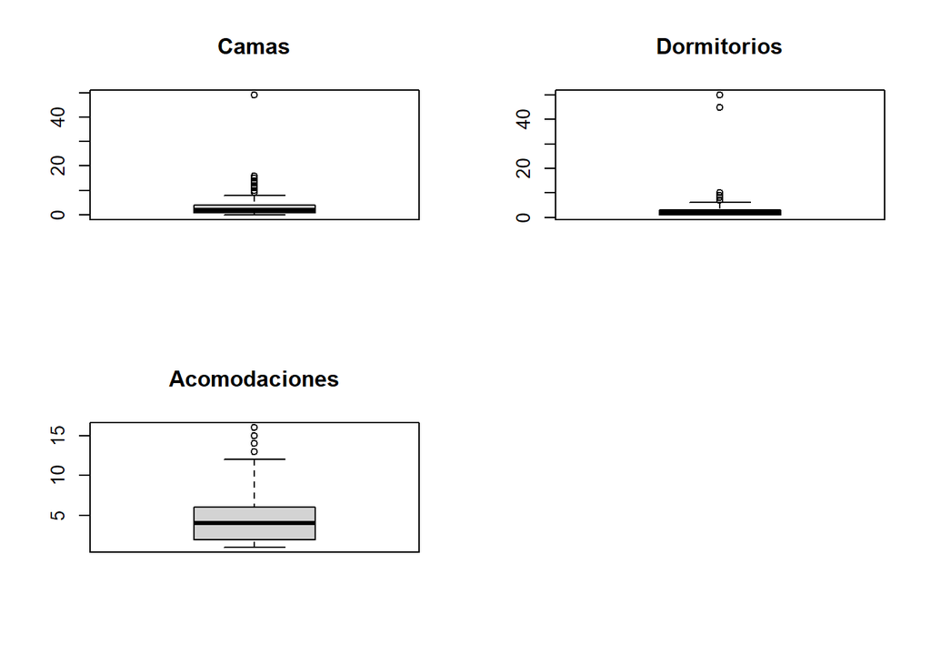

```r
boxplot(AUS$camas,main="Camas")
boxplot(AUS$dormitorios,main="Dormitorios")
boxplot(AUS$acomodaciones,main="Acomodaciones")

par(mfrow=c(1,1))
```

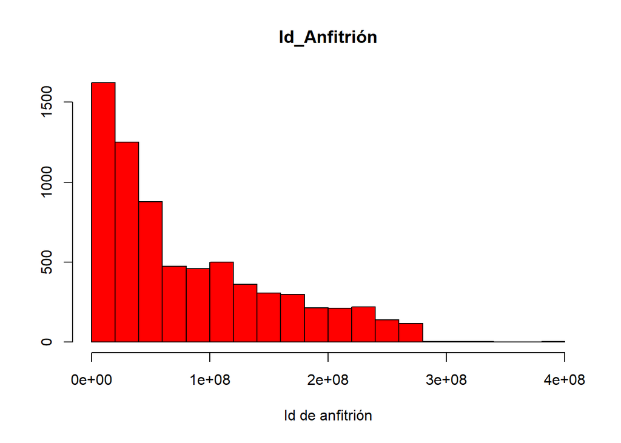

```r
#Histogramas de las variables cuantitativas
hist(AUS$id_anfitrion,main="Id_Anfitrión",xlab="Id de anfitrión",ylab="",col="red")
```

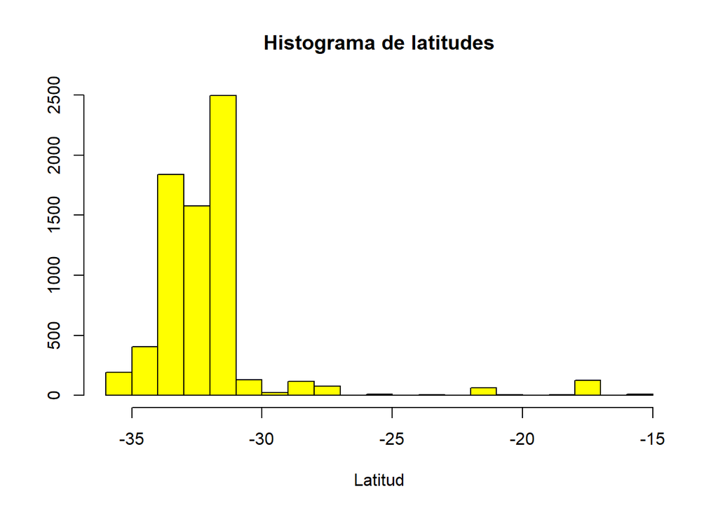

```r
hist(AUS$latitud,main="Histograma de latitudes",xlab="Latitud",ylab="",col="yellow")
```

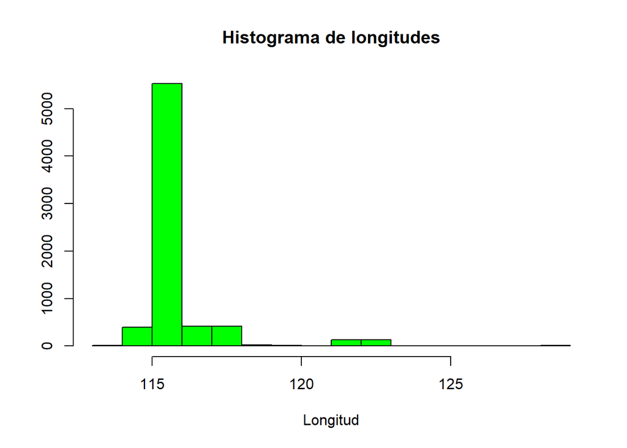

```r
hist(AUS$longitud,main="Histograma de longitudes",xlab="Longitud",ylab="",col="green")
```

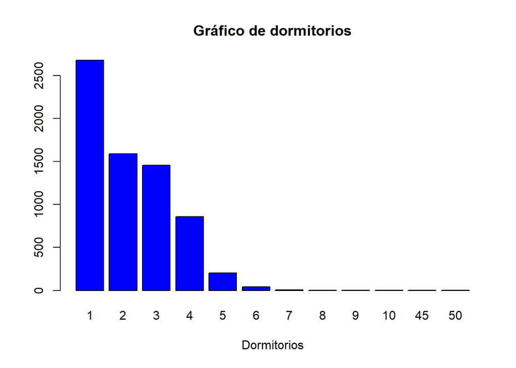

```r
barplot(table(AUS$dormitorios),col = "blue",main = "Gráfico de dormitorios",xlab = "Dormitorios",ylab="")
```

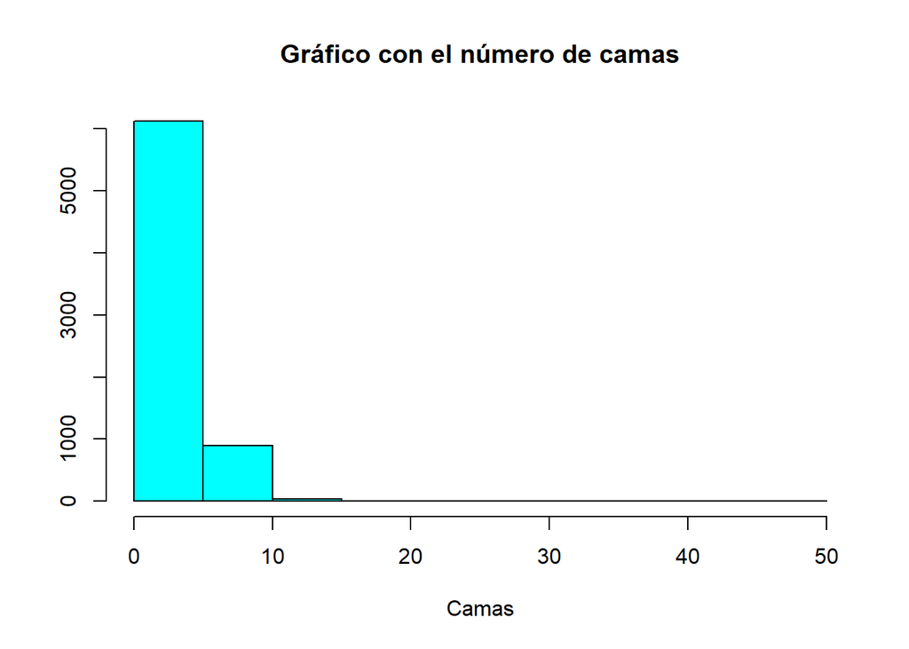

```r
hist(AUS$camas,main="Gráfico con el número de camas",xlab="Camas",col="cyan",ylab="")
```

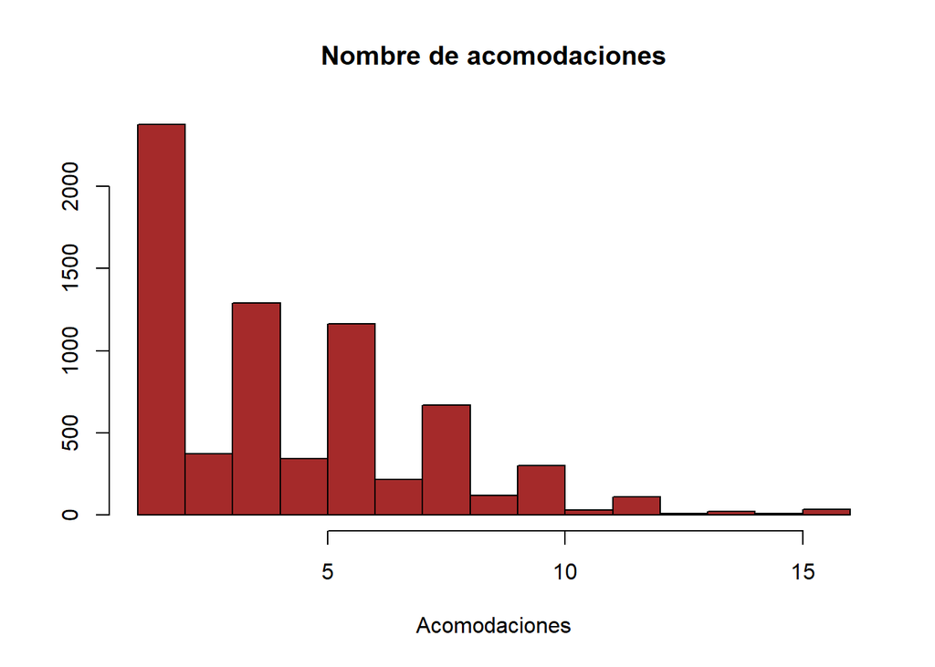

```r
hist(AUS$acomodaciones,main="Nombre de acomodaciones",xlab="Acomodaciones",col="brown",ylab="")
```

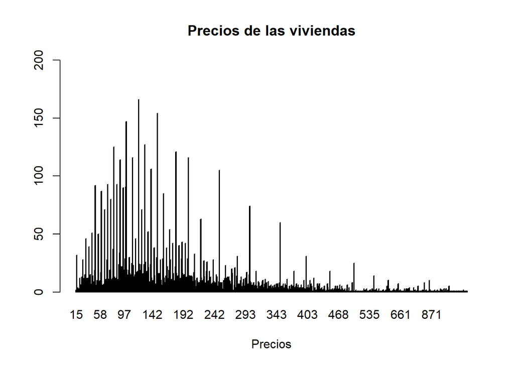

```r
#Hacemos un barplot y no un histograma para la variable precio, ya que los datos se ven mucho más claros
barplot(table(AUS$precio),main="Precios de las viviendas",xlab="Precios",ylim=c(0,200))
```

6. Dibuja un diagrama de tarta para una de las variables no numéricas agrupando como “Otros” los valores que representen un porcentaje inferior al 1% del total.

## Solución apartado 6

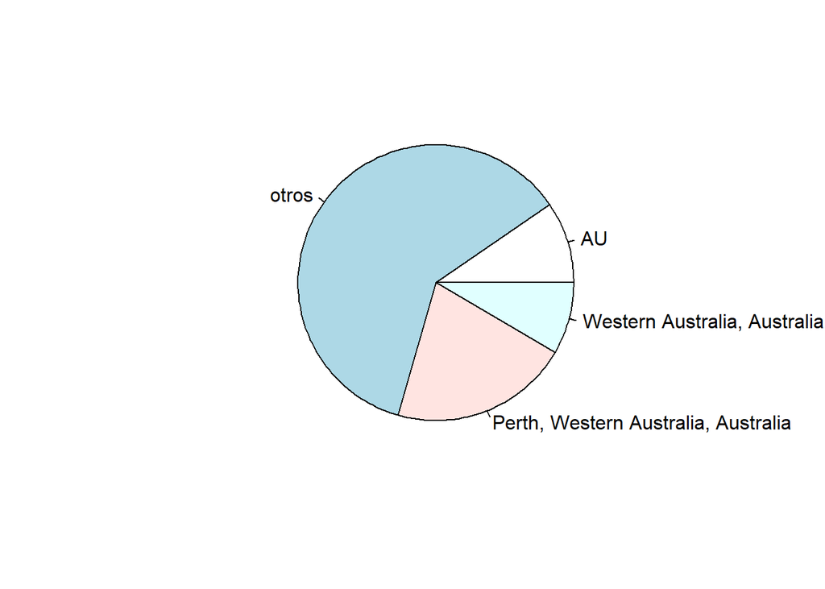

```r
#Pasamos la variable a un dato de tipo caracter
var =as.character(AUS$localización)

#Insertamos en una variabla la tabla de frecuencias relativas de localización
tbl=prop.table(table(var))

#Identificamos, que valores de la variable localización suponen menos del 5%
#(hemos puesto los que suponen menos del 5% y no los que suponen el 1% porque
#el diagrama queda mucho mas claro)
otros= names(tbl)[which(tbl<=0.05)]

#Cambiamos los valores que suponen menos del 1% del total por el nombre "otros"
var[var %in% otros]="otros"

#Diagrama de pastel de la variable localización
pie(prop.table(table(var)))
```

7. Calcular el valor medio de alguna de las variables numéricas según el barrio, de menor a mayor y sin tener en cuenta nombres de Barrio incorrectas ( `""` o `"N/A"`).

## Solución apartado 7

```r
#Creamos nuestro dataframe modificado a partir de 2 variables
d = data.frame(Barrio=AUS$vecindario,precio=AUS$precio )

#Creamos un segundo dataframe donde relacionamos las variables Barrio y precio, haciendo la mediana
Stats <- d %>% group_by(Barrio) %>% summarize(Media = mean(precio, na.rm = TRUE))

#Ordenamos las 5 primeras medianas
mediabaja=head(Stats %>% arrange(Media),5)
mediaalta=head(Stats %>% arrange(desc(Media)),5)

#Visualización
mediabaja
```

```
## # A tibble: 5 x 2
##   Barrio                                  Media
##   <chr>                                   <dbl>
## 1 Moora, Western Australia, Australia      15
## 2 Nilgen, Western Australia, Australia     25
## 3 Riverton, Western Australia, Australia   29
## 4 Lockridge, Western Australia, Australia  33
## 5 Parmelia, Western Australia, Australia   33.5
```

```r
mediaalta
```

```
## # A tibble: 5 x 2
##   Barrio                                    Media
##   <chr>                                     <dbl>
## 1 Bovell, Western Australia, Australia      1050.
## 2 Bramley, Western Australia, Australia      973
## 3 Wonnerup, Western Australia, Australia     688.
## 4 Camballin, Western Australia, Australia    601
## 5 Perth Hills, Western Australia, Australia  595
```

8. Dibuja un **boxplot** de la variable precio, para los 5 barrios más caros (precio medio más alto) y los 5 barrios más baratos (precio medio más bajo), en un mismo diagrama. Los **boxplots** deben indicar también el valor medio de los datos.

## Solución apartado 8

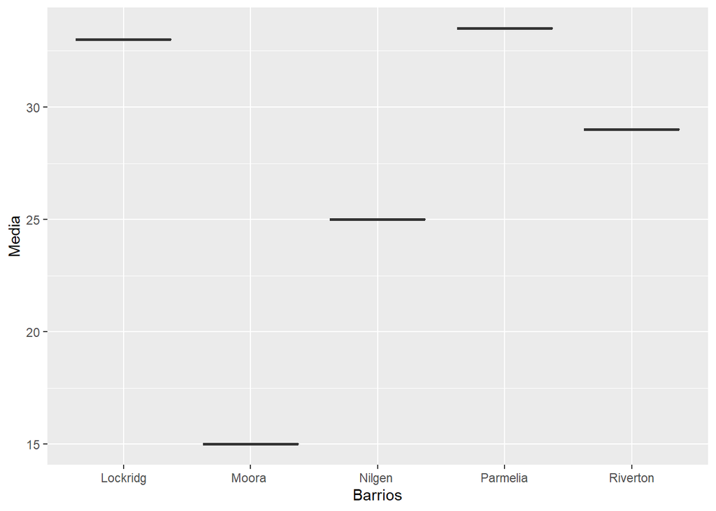

```r
#Eliminamos el String "Western Australia,Australia" mediante un substring
barrio2=substr(mediabaja$Barrio, 1, 8)
Barrios=(gsub(pattern = "[\\W]|[,]",replacement = "", barrio2))


#Boxplot de la media de los 5 más barrios más baratos
p <- ggplot(mediabaja, aes(x=Barrios, y=Media)) +
  geom_boxplot()
p
```

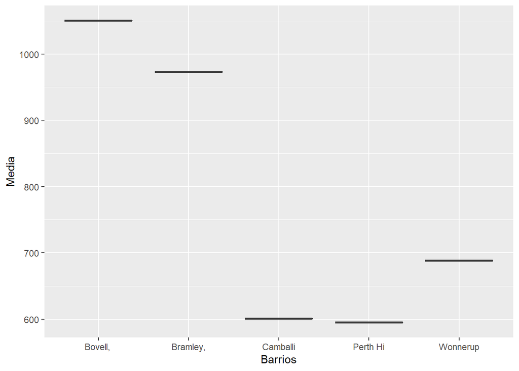

```r
#Asignamos a Barrios los nombres de los barrios más caros
barrio2=substr(mediaalta$Barrio, 1, 8)
Barrios=barrio2

#Boxplot de la media de los 5 barrios más caros
q <- ggplot(mediaalta, aes(x=Barrios, y=Media)) +
  geom_boxplot()
q
```

9. Para 4 de las variables numéricas dibujar los diagramas de dispersión dos a dos, con colores diferentes para cada barrio ( “neighbourhood”).

## Solución apartado 9

```r
# numero zonas
n=length(unique(AUS$vecindario))
n
```

```
## [1] 637
```

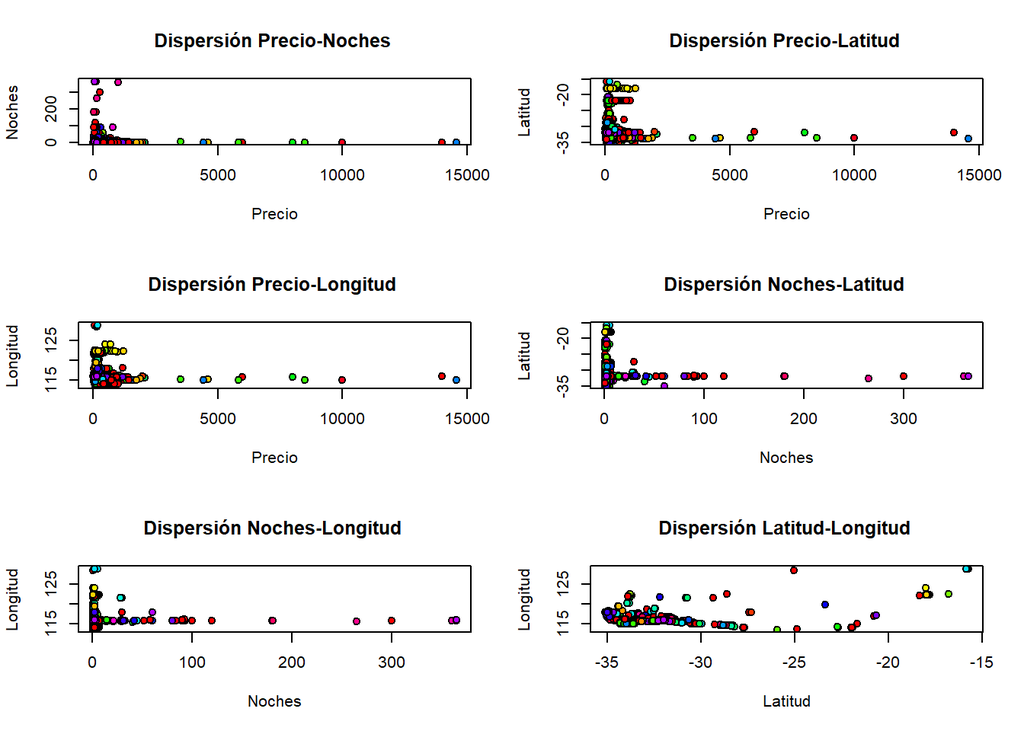

```r
par(mfrow=c(3,2))

#Diagrama de dispersión Precio-Noches
plot(AUS$precio,AUS$noches_minimas, main = "Dispersión Precio-Noches ",
      pch = 21, bg = rainbow(n)[factor(AUS$vecindario)],xlab="Precio",ylab="Noches")

#Diagrama de dispersión Precio-Latitud
plot(AUS$precio,AUS$latitud, main = "Dispersión Precio-Latitud ",
      pch = 21, bg = rainbow(n)[factor(AUS$vecindario)],xlab="Precio",ylab="Latitud")

#Diagrama de dispersión Precio-Longitud
plot(AUS$precio,AUS$longitud, main = "Dispersión Precio-Longitud ",
      pch = 21, bg = rainbow(n)[factor(AUS$vecindario)],xlab="Precio",ylab="Longitud")

#Diagrama de dispersión Noches-Latitud
plot(AUS$noches_minimas,AUS$latitud, main = "Dispersión Noches-Latitud ",
      pch = 21, bg = rainbow(n)[factor(AUS$vecindario)],xlab="Noches",ylab="Latitud")

#Diagrama de dispersión Noches-Longitud
plot(AUS$noches_minimas,AUS$longitud, main = "Dispersión Noches-Longitud ",
      pch = 21, bg = rainbow(n)[factor(AUS$vecindario)],xlab="Noches",ylab="Longitud")

#Diagrama de dispersión Latitud-Longitud
plot(AUS$latitud,AUS$longitud, main = "Dispersión Latitud-Longitud ",
      pch = 21, bg = rainbow(n)[factor(AUS$vecindario)],xlab="Latitud",ylab="Longitud")
```

```r
par(mfrow=c(1,1))
```

10. Por las mismas variables elegidas en el apartado anterior calcular los coeficientes de correlación dos a dos de las variables, sin tener en cuenta los valores `NA`.

## Solución apartado 10

```r
#Calculamos las correlaciones dos a dos para las variables anteriores
cor1=na.omit(cor(AUS$noches_minimas,AUS$precio))
cor1
```

```
## numeric(0)
## attr(,"na.action")
## [1] 1
## attr(,"class")
## [1] "omit"
```

```r
cor2=na.omit(cor(AUS$noches_minimas,AUS$longitud))
cor2
```

```
## numeric(0)
## attr(,"na.action")
## [1] 1
## attr(,"class")
## [1] "omit"
```

```r
cor3=na.omit(cor(AUS$noches_minimas,AUS$latitud))
cor3
```

```
## numeric(0)
## attr(,"na.action")
## [1] 1
## attr(,"class")
## [1] "omit"
```

```r
cor4=na.omit(cor(AUS$precio,AUS$latitud))
cor4
```

```
## numeric(0)
## attr(,"na.action")
## [1] 1
## attr(,"class")
## [1] "omit"
```

```r
cor5=na.omit(cor(AUS$precio,AUS$longitud))
cor5
```

```
## numeric(0)
## attr(,"na.action")
## [1] 1
## attr(,"class")
## [1] "omit"
```

```r
cor6=na.omit(cor(AUS$latitud,AUS$longitud))
cor6
```

```
## numeric(0)
## attr(,"na.action")
## [1] 1
## attr(,"class")
## [1] "omit"
```

11. Selecciona dos variables numéricas, y para cada una de ellas organiza sus valores en un máximo de 5 intervalos con ala función `cut`.

## Solución apartado 11

```r
#Hacemos subdivisiones de las variables precio y dormitorios
corte1=cut(AUS$precio, breaks=c(0,100,200,300,600,Inf), include.lowest = TRUE)
corte10=na.omit(corte1)
corte10[1:10]
```

```
##  [1] [0,100]   [0,100]   [0,100]   (200,300] [0,100]   [0,100]   [0,100]
##  [8] (100,200] [0,100]   [0,100]
## Levels: [0,100] (100,200] (200,300] (300,600] (600,Inf]
```

```r
corte2= cut(AUS$dormitorios, breaks=c(0,2,4,6,8,Inf), include.lowest = TRUE)
corte20=na.omit(corte2)
corte20[1:10]
```

```
##  [1] [0,2] [0,2] [0,2] (4,6] [0,2] [0,2] [0,2] [0,2] [0,2] [0,2]
## Levels: [0,2] (2,4] (4,6] (6,8] (8,Inf]
```

12. A partir de los datos en intervalos obtenidos en el apartado anterior construid una tabla de contingencia de las dos variables y dibuja el diagrama de mosaico asociado a la mesa.

## Solución apartado 12

```r
#Tabla de contingencia de las variables que hemos creado en el apartado anterior
table(corte10)
```

```
## corte10
##   [0,100] (100,200] (200,300] (300,600] (600,Inf]
##      2081      2676      1205       905       201
```

```r
table(corte20)
```

```
## corte20
##   [0,2]   (2,4]   (4,6]   (6,8] (8,Inf]
##    4266    2312     245      10       6
```

[figure not shown]

```r
#Diagrama de mosaico de las dos variables que hemos creado en el apartado anterior
plot(corte2,corte1, col="purple",ylab="Dormitorios",xlab="Precio")
```